# BaSiC

Wei Sun

1/3/2019

This R markdown file illustrate the usage of R package `basic` with application on the bulk smaple and single cell sequencing data generated by Wang et al. (2014) *Clonal evolution in breast cancer revealed by single nucleus genome sequencing*. Nature, 512(7513), 155-160.

```r
library(basic)
library(ggcorrplot)
library(gridExtra)
```

First read in the somatic mutaton calls and read-depth information from bulk tumor and single cells.

```r
load("data/wang_2014.RData")
ls()
```

```
## [1] "asrec"          "mutations.bulk" "mutations.sc"   "trec"
```

```r
dim(mutations.bulk)
```

```
## [1] 789  12
```

```r
mutations.bulk[1:2,]
```

```
##   contig position context ref_allele alt_allele tumor_name normal_name
## 1   chr1  2399526 GCGxCTG          G          A SRR1298936  SRR1163508
## 2   chr1  2406772 GCCxCTG          G          A SRR1298936  SRR1163508
##   t_ref_count t_alt_count failure_reasons judgement totalCN
## 1          43          23              NA      KEEP       2
## 2          54          36              NA      KEEP       2
```

```r
dim(mutations.sc)
```

```
## [1] 789  16
```

```r
mutations.sc[1:2,]
```

```
##              a1 a2 a3 a4 a5 a6 a7 a8 h1 h2 h3 h4 h5 h6 h7 h8
## chr1:2399526 NA  1  1 NA  1 NA  1  0 NA  1 NA NA NA  0 NA  1
## chr1:2406772  1  1  1  0  1 NA  1  1 NA  1 NA NA NA  0 NA  1
```

We have filtered the somatic mutations so that the copy number is either 2 or 1.

```r
table(mutations.bulk$totalCN)
```

```
##
##   1   2
## 185 604
```

Among 789x16 = 12624 entries in the mutation data matrix for the 789 loci and 16 single cells, 4562 ($\sim 36\%$) entries are missing due to low read-depth.

```r
table(c(mutations.sc), useNA="ifany")
```

```
##
##    0    1 <NA>
## 1339 6723 4562
```

```r
table(is.na(mutations.sc))/12624
```

```
##
##     FALSE      TRUE
## 0.6386248 0.3613752
```

Next we cluster the mutations based on the data from single cells. This involves imputing the missing values in single cell mutation calls. We evaluate the resutls with number of clusters being 2, 3, or 4. In the following resutls, `scs$n2` and `scs$n3` indicate results for 2 or 3 clusters, respectively.

```r
scs = cluster.SCS(mutations.sc, asrec, trec, nclust=2:4)
```

```
## nclust = 2, time: Thu Jan  3 13:27:22 2019
```

```
## iteration 100, time: Thu Jan  3 13:27:31 2019
```

```
## iteration 200, time: Thu Jan  3 13:27:40 2019
```

```
## iteration 300, time: Thu Jan  3 13:27:49 2019
```

```
## nclust = 3, time: Thu Jan  3 13:27:49 2019
```

```
## iteration 100, time: Thu Jan  3 13:27:59 2019
```

```
## iteration 200, time: Thu Jan  3 13:28:08 2019
```

```
## iteration 300, time: Thu Jan  3 13:28:18 2019
```

```
## nclust = 4, time: Thu Jan  3 13:28:23 2019
```

```
## iteration 100, time: Thu Jan  3 13:28:32 2019
```

```
## iteration 200, time: Thu Jan  3 13:28:43 2019
```

```
## iteration 300, time: Thu Jan  3 13:28:54 2019
```

```r
names(scs)
```

```
## [1] "n2"              "n3"              "n4"              "nclust.by.BIC"
## [5] "summary.cluster"
```

```r
scs$summary.cluster
```

```
##    nclust       BIC nIt          gap
## n2      2  90647.88 305 9.997198e-06
## n3      3 106375.38 352 9.911290e-06
## n4      4 115328.83 354 9.952404e-06
```

```r
scs$nclust.by.BIC
```

```
## [1] "n2"
```

```r
scs$n2$theta
```

```
##       alpha1        beta1       alpha2        beta2          pi1
## 6.411534e-11 9.070801e-01 7.984080e-01 9.143012e-01 7.857542e-02
##         rho1          pi2         rho2          pi3         rho3
## 2.643041e-01 4.815755e-01 2.840097e-01 9.760736e-01 1.403657e-01
##         psi1         psi2
## 9.647900e-02 5.270801e-01
```

```r
scs$n3$theta
```

```
##       alpha1        beta1       alpha2        beta2          pi1
## 1.518819e-15 9.072108e-01 7.992564e-01 9.142481e-01 7.857542e-02
##         rho1          pi2         rho2          pi3         rho3
## 2.643041e-01 4.815755e-01 2.840097e-01 9.760736e-01 1.403657e-01
##         psi1         psi2
## 9.647900e-02 5.270801e-01
```

Next we perform joint anlaysis of bulk tumor data and single cell data.

```r
b.cn    = mutations.bulk$totalCN
b.asrec = mutations.bulk$t_alt_count
b.trec  = mutations.bulk$t_alt_count + mutations.bulk$t_ref_count

cBSC = cluster.BSC(b.cn, b.asrec, b.trec, mutations.sc, asrec, trec,
                   nclusters=2:4)
```

```
## initialize mutation calls in single cells
```

```
## fit mixture of beta-binomials, stratified by maf
```

```
## ...................
## nclust = 2, time: Thu Jan  3 13:35:30 2019
##
## iteration 100, time: Thu Jan  3 13:35:40 2019
##
## iteration 200, time: Thu Jan  3 13:35:50 2019
##
## nclust = 3, time: Thu Jan  3 13:35:56 2019
##
## iteration 100, time: Thu Jan  3 13:36:06 2019
##
## iteration 200, time: Thu Jan  3 13:36:17 2019
##
## iteration 300, time: Thu Jan  3 13:36:30 2019
##
## iteration 400, time: Thu Jan  3 13:36:41 2019
##
## iteration 500, time: Thu Jan  3 13:36:52 2019
##
## iteration 600, time: Thu Jan  3 13:37:03 2019
##
## iteration 700, time: Thu Jan  3 13:37:13 2019
##
## nclust = 4, time: Thu Jan  3 13:37:25 2019
##
## iteration 100, time: Thu Jan  3 13:37:38 2019
##
## iteration 200, time: Thu Jan  3 13:37:50 2019
##
## iteration 300, time: Thu Jan  3 13:38:02 2019
##
## iteration 400, time: Thu Jan  3 13:38:14 2019
```

```r
names(cBSC)
```

```
## [1] "n2"              "n3"              "n4"              "nclust.by.BIC"
## [5] "summary.cluster"
```

```r
cBSC$summary.cluster
```

```
##    nclust      BIC nIt          gap
## n2      2 29637.36 257 9.893304e-06
## n3      3 31672.31 790 9.934172e-06
## n4      4 31786.95 412 9.719609e-06
```

```r
cBSC$nclust.by.BIC
```

```
## [1] "n2"
```

Next we perform joint anlaysis of bulk tumor data and single cell data, without accouting for copy number information. To do this, we just set the copy number input to be 2 for all loci.

```r
b.cn  = rep(2, length(b.asrec))
cBSC2 = cluster.BSC(b.cn, b.asrec, b.trec, mutations.sc, asrec, trec,
                    nclusters=2:4)
```

```
## initialize mutation calls in single cells
```

```
## fit mixture of beta-binomials, stratified by maf
```

```
## ...................
## nclust = 2, time: Thu Jan  3 13:45:08 2019
##
## iteration 100, time: Thu Jan  3 13:45:19 2019
##
## iteration 200, time: Thu Jan  3 13:45:29 2019
##
## iteration 300, time: Thu Jan  3 13:45:40 2019
##
## iteration 400, time: Thu Jan  3 13:45:51 2019
##
## iteration 500, time: Thu Jan  3 13:46:02 2019
##
## iteration 600, time: Thu Jan  3 13:46:13 2019
##
## nclust = 3, time: Thu Jan  3 13:46:16 2019
##
## iteration 100, time: Thu Jan  3 13:46:27 2019
##
## iteration 200, time: Thu Jan  3 13:46:39 2019
##
## nclust = 4, time: Thu Jan  3 13:46:47 2019
##
## iteration 100, time: Thu Jan  3 13:46:59 2019
##
## iteration 200, time: Thu Jan  3 13:47:12 2019
##
## iteration 300, time: Thu Jan  3 13:47:26 2019
```

```r
names(cBSC2)
```

```
## [1] "n2"              "n3"              "n4"              "nclust.by.BIC"
## [5] "summary.cluster"
```

```r
cBSC2$summary.cluster
```

```
##    nclust      BIC nIt          gap
## n2      2 30190.03 628 9.904403e-06
## n3      3 29492.42 270 9.982792e-06
## n4      4 31449.35 351 9.838839e-06
```

```r
cBSC2$nclust.by.BIC
```

```
## [1] "n3"
```

```r
scs$n2$nu
```

```
## [1] 0.97591888 0.02408112
```

```r
cBSC$n2$nu
```

```
## [1] 0.97718642 0.02281358
```

```r
cBSC2$n3$nu
```

```
## [1] 0.97085917 0.01012946 0.01901137
```

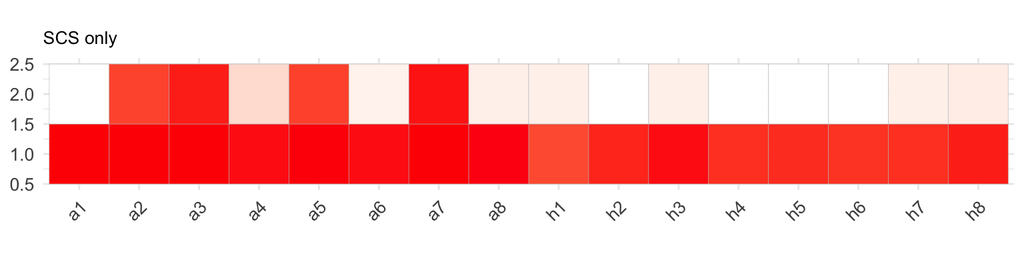

```r
g0 = ggcorrplot(scs$n2$gamma, tl.cex=10, lab = FALSE, show.legend=F) +
  ggtitle('SCS only') + theme(plot.title = element_text(size = 10))

g1 = ggcorrplot(cBSC$n2$gamma, tl.cex=10, lab = FALSE, show.legend=F) +
  ggtitle("BaSiC w/ CNA") + theme(plot.title = element_text(size = 10))

g2 = ggcorrplot(cBSC2$n3$gamma, tl.cex=10, lab = FALSE, show.legend=F) +
  ggtitle("BaSiC w/o CNA") + theme(plot.title = element_text(size = 10))

g0
```

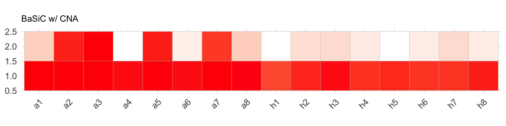

```r
g1
```

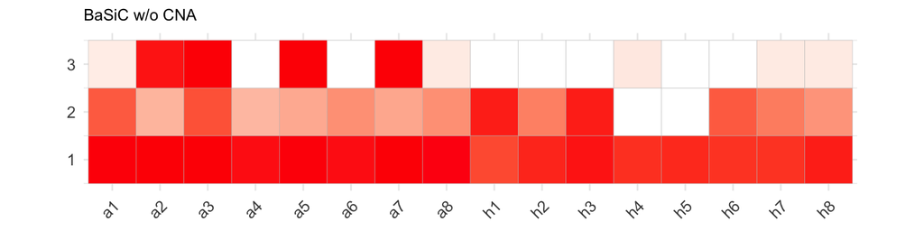

```r
g2
```

Finally, we check mutation classification based on the three approaches.

```r
colSums(scs$n2$postPs)
```

```
## [1] 770  19
```

```r
colSums(cBSC$n2$postPs)
```

```
## [1] 771.00009  17.99991
```

```r
colSums(cBSC2$n3$postPs)
```

```
## [1] 766.007883   7.992146  14.999971
```

```r
mut.scs = apply(scs$n2$postPs, 1, which.max)
mut.bsc = apply(cBSC$n2$postPs, 1, which.max)
mut.bsc.nocn = apply(cBSC2$n3$postPs, 1, which.max)

t2 = table(mut.bsc, mut.scs)
t3 = table(mut.bsc, mut.bsc.nocn)
t4 = table(mut.scs, mut.bsc.nocn)

ts = cbind(t2, t3)
ts
```

```
##     1  2   1 2  3
## 1 767  4 766 5  0
## 2   3 15   0 3 15
```

```r
t4
```

```
##        mut.bsc.nocn
## mut.scs   1   2   3
##       1 763   6   1
##       2   3   2  14
```